# Modeling Quality of Suggestions

Yu-Chih (Wisdom) Chen

5/4/2022

## Introduction

This report consists of five key sections:

- Introduction
- Data Cleanup and Transformation
- Exploratory Data Analysis
- Model Selection and Self-Comparison
- Conclusion

Because the primary task of this analysis centers around model design and performance, we focused on exploring, tuning and analyzing a variety of classification methods. This includes logistic regression, decision-trees, and Naive Bayes. For each method, we included a confusion matrix, ROC objects and curves, and calculated the AUC, from which we could extract key performance metrics. As we initially embarked on this project, we did no assume whether or not certain models would perform better. Instead, we were interested to see how the different models would handle this unique data and were curious to see which model would perform the best.

Before running this file, ensure that the file `suggestions.csv` is in the same directory as this file.

## Data Cleanup & Transformation

##### We will begin by loading packages that we will need to perform our analysis.

```r
library(ggplot2)
library(plyr)
library(ISLR)
library(MASS)
library(knitr)
library(rpart)
library(dplyr)
library(partykit)
library(gridExtra)
library(ROSE)
library(caret)
library(rms)
library(ROCR)
library(klaR)
library(unbalanced)
library(pROC)
library(randomForest)
library(mlr)
library(broom)
library(modelr)
options(warn=-1)

cbPalette <- c("#999999", "#E69F00", "#56B4E9", "#009E73", "#F0E442", "#0072B2", "#D55E00", "#CC79A7")

options(scipen = 4)
```

##### Load data

```r
suggestions <- read.csv("suggestions.csv")
```

```r
colnames(suggestions)
```

```
##  [1] "Recommended"
##  [2] "Suggestion_Id"
##  [3] "Responses"
##  [4] "Views"
##  [5] "Votes_Up"
##  [6] "Votes_Down"
##  [7] "Author_Id"
##  [8] "Author_Join..in.terms.of.how.many.days.since.they.joined."
##  [9] "Author_TotalPosts"
## [10] "Author_PostsPerDay"
```

```r
## To check the missing value in data set

sum(is.na(suggestions))
```

```
## [1] 0
```

-*Great! The dataset has no missing values.*

## Exploratory Data Analysis (EDA)

```r
colnames(suggestions)
```

```
##  [1] "Recommended"
##  [2] "Suggestion_Id"
##  [3] "Responses"
##  [4] "Views"
##  [5] "Votes_Up"
##  [6] "Votes_Down"
##  [7] "Author_Id"
##  [8] "Author_Join..in.terms.of.how.many.days.since.they.joined."
##  [9] "Author_TotalPosts"
## [10] "Author_PostsPerDay"
```

```r
# The 8th column name is especially large
names(suggestions)[names(suggestions) == "Author_Join..in.terms.of.how.many.days.since.they.joined."] <- "Author_emplyd_days"

colnames(suggestions)
```

```
##  [1] "Recommended"        "Suggestion_Id"      "Responses"
##  [4] "Views"              "Votes_Up"           "Votes_Down"
##  [7] "Author_Id"          "Author_emplyd_days" "Author_TotalPosts"
## [10] "Author_PostsPerDay"
```

-We have 9 predictor variables to work with in terms of predicting which suggestions will be Recommended.  
`Author_Join..in.terms.of.how.many.days.since.they.joined.` is a very long variable name, we chose to rename it to `Author_emplyd_days` to shorten the name.

-*We expect that there may collinearity between some of these variables, such as `Author_emplyd_days` and `Author_PostsPerDay`. We will look at potential collinearity as a part of our EDA.*

```r
table(suggestions$Recommended)
```

```
##
##     0     1
## 15867   562
```

-*This is clearly an unbalanced distribution. Most of the suggestions were not recommended. We will need to address this prior to training models.*

##### Checking for Collinearity

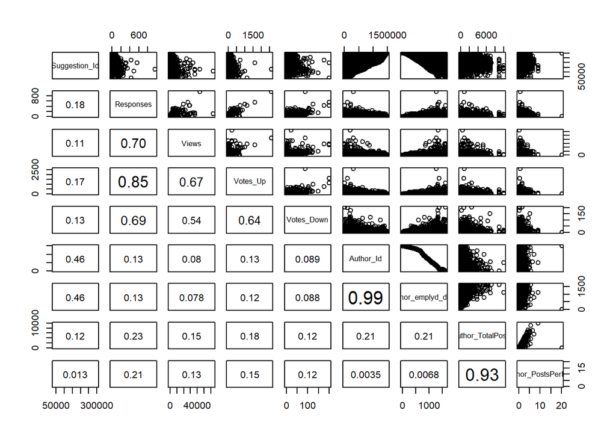

```r
# checking for correlation
suggestion_vars <-c("Suggestion_Id" , "Responses" , "Views" , "Votes_Up", "Votes_Down" , "Author_Id" , "Author_emplyd_days" , "Author_TotalPosts" , "Author_PostsPerDay")

#version w/ only plots
#pairs(bikes[,bike_vars])

panel.cor <- function(x, y, digits = 2, prefix = "", cex.cor, ...)
{
    usr <- par("usr"); on.exit(par(usr))
    par(usr = c(0, 1, 0, 1))
    r <- abs(cor(x, y))
    txt <- format(c(r, 0.123456789), digits = digits)[1]
    txt <- paste0(prefix, txt)
    if(missing(cex.cor)) cex.cor <- 0.8/strwidth(txt)
    text(0.5, 0.5, txt, cex = pmax(1, cex.cor * r))
}

pairs(suggestions[,suggestion_vars],lower.panel = panel.cor)
```

##### Correlation Plots

-*In this section we will take a closer look and “zoom in” at the correlations between a select few variables.*

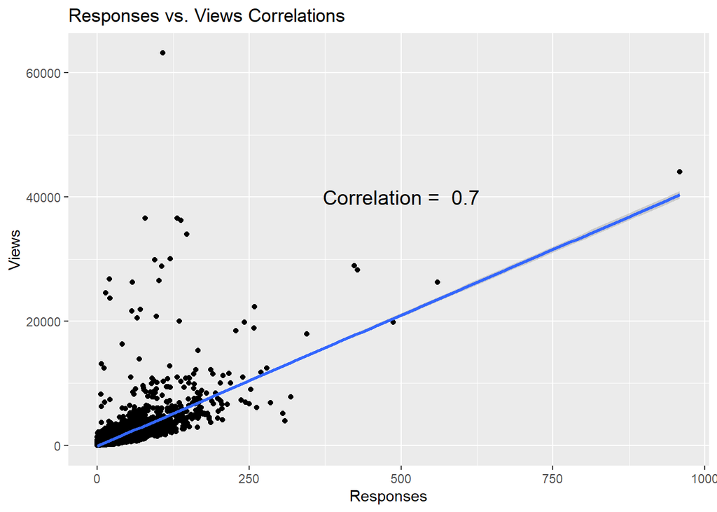

```r
# Perform `Response` vs `Views`

ggplot(suggestions, aes(x = Responses, y = Views)) +
    annotate(x = 500, y = 40000,
         label=paste("Correlation = ", round(cor(suggestions$Responses, suggestions$Views),2)),
         geom = "text", size = 5)+
  labs(title = "Responses vs. Views Correlations", y = "Views", x = "Responses")+
  geom_point()+
  geom_smooth(method = lm)
```

-*The plot above indicates that `Views` and `Responses` have a 70% correlation rate, which means they are highly correlated.*

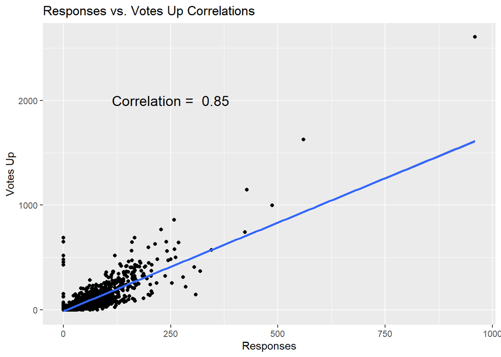

```r
# Perform `Responses` vs. `Votes_Up`

ggplot(suggestions, aes(x = Responses, y = Votes_Up)) +
      annotate(x = 250, y = 2000,
         label=paste("Correlation = ", round(cor(suggestions$Responses, suggestions$Votes_Up),2)),
         geom = "text", size = 5)+
  labs(title = "Responses vs. Votes Up Correlations", y = "Votes Up", x = "Responses")+
  geom_point()+
  geom_smooth(method = lm)
```

-*The plot above indicates that `Votes_Up` and `Responses` have a 85% correlation rate, which means they are highly correlated.*

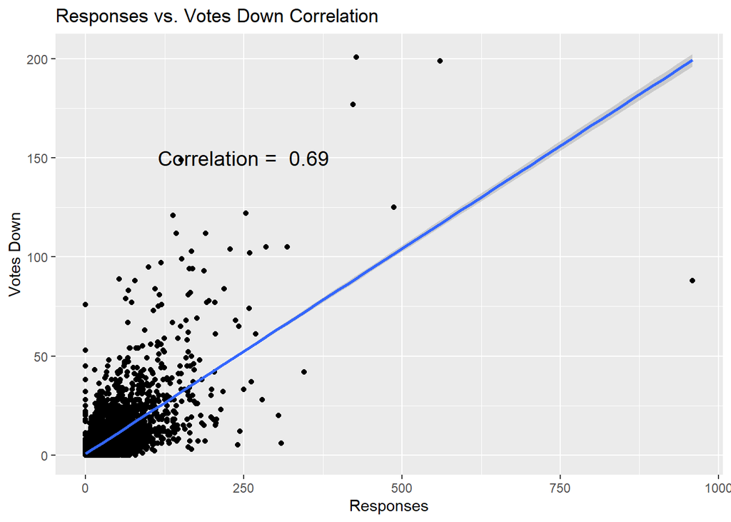

```r
# Perform `Responses` vs. `Votes_Down`

ggplot(suggestions, aes(x = Responses, y = Votes_Down)) +
        annotate(x = 250, y = 150,
         label=paste("Correlation = ", round(cor(suggestions$Responses, suggestions$Votes_Down),2)),
         geom = "text", size = 5)+
  labs(title = "Responses vs. Votes Down Correlation", y = "Votes Down", x = "Responses")+
  geom_point()+
  geom_smooth(method = lm)
```

-*The plot above indicates that `Votes_Down` and `Responses` have a 69% correlation rate, which means they are moderately correlated- if we consider anything 70% and above as highly correlated. They are less correlated than `Votes_Up` and `Responses` though.*

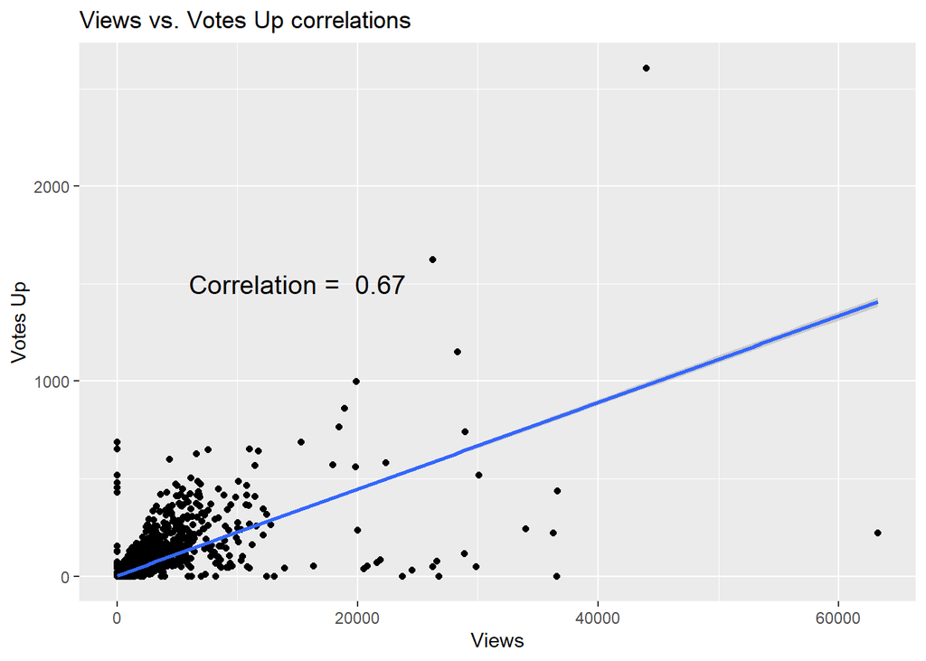

```r
# Perform `Views` vs. `Votes_Up`

ggplot(suggestions, aes(x = Views, y = Votes_Up)) +
          annotate(x = 15000, y = 1500,
         label=paste("Correlation = ", round(cor(suggestions$Views, suggestions$Votes_Up),2)),
         geom = "text", size = 5)+
  labs(title = "Views vs. Votes Up correlations", y = "Votes Up", x = "Views")+
  geom_point()+
  geom_smooth(method = lm)
```

-*The plot above indicates that `Votes_Up` and `Views` have a 67% correlation rate, which means they are moderately correlated.*

##### Density Plots

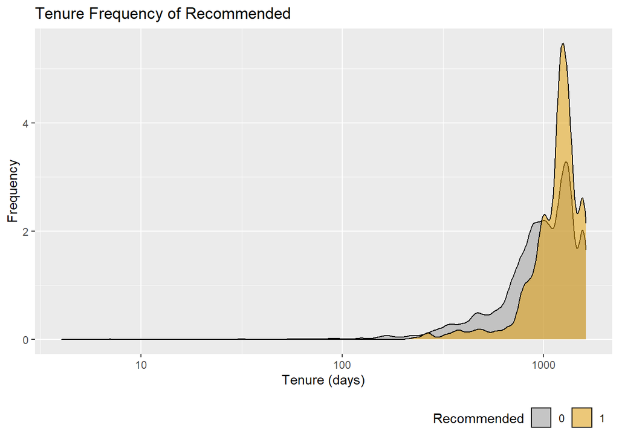

```r
plot_2 <- ggplot(suggestions, aes(x = Author_emplyd_days, fill = as.factor(Recommended))) +
  geom_density(alpha=.5) +
  scale_x_log10()+
  labs(fill='Recommended')+
  scale_fill_manual(values = c('#999999','#E69F00')) +
  labs(title = "Tenure Frequency of Recommended", y = "Frequency", x = "Tenure (days)")+
  theme(legend.position = "bottom",
    legend.justification = c("right", "top"),
    legend.box.just = "right")

plot_2
```

```r
tenure_rec <- round(mean(suggestions$Author_emplyd_days[suggestions$Recommended>0]),3)
tenure_nonrec <- round(mean(suggestions$Author_emplyd_days[suggestions$Recommended<1]),3)

print(paste("The average tenure of recommended suggestions is: ", tenure_rec))
```

```
## [1] "The average tenure of recommended suggestions is:  1172.801"
```

```r
print(paste("The average tenure of suggestions that were not recommended is: ", tenure_nonrec))
```

```
## [1] "The average tenure of suggestions that were not recommended is:  1016.846"
```

-*The plot above indicates that age/tenure does matter when it comes to an employee’s ability to make a good suggestion. As the text output along with the plot indicates, it appears that employees with longer tenures make better suggestions than those with shorter ones.*

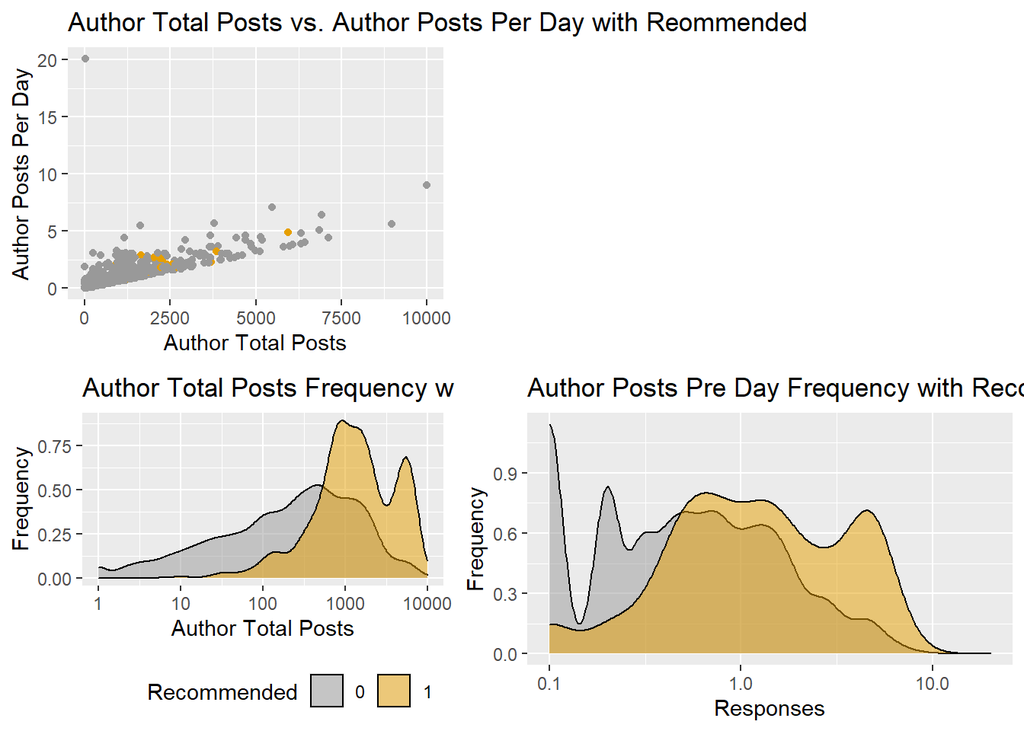

```r
plot_1 <- ggplot(suggestions,aes(x = Author_TotalPosts, y = Author_PostsPerDay, color = as.factor(Recommended))) +
  geom_point() +
  labs(title = "Author Total Posts vs. Author Posts Per Day with Reommended", y = "Author Posts Per Day", x = "Author Total Posts")+
  scale_color_manual(values = c('#999999','#E69F00')) +
  theme(legend.position = "none")


plot_2 <- ggplot(suggestions, aes(x = Author_TotalPosts, fill = as.factor(Recommended))) +
  geom_density(alpha=.5) +
  scale_x_log10()+
  labs(fill='Recommended')+
  scale_fill_manual(values = c('#999999','#E69F00')) +
  labs(title = "Author Total Posts Frequency with Recommended", y = "Frequency", x = "Author Total Posts")+
  theme(legend.position = "bottom",
    legend.justification = c("right", "top"),
    legend.box.just = "right")


plot_3 <- ggplot(suggestions, aes( x = Author_PostsPerDay, fill = as.factor(Recommended))) +
  geom_density(alpha=.5) +
  scale_x_log10()+
  scale_fill_manual(values = c('#999999','#E69F00')) +
  labs(title = "Author Posts Pre Day Frequency with Recommended", y = "Frequency", x = "Responses")+
  theme(legend.position = "none")



blankPlot <- ggplot()+geom_blank(aes(1,1))+
  theme(plot.background = element_blank(),
   panel.grid.major = element_blank(),
   panel.grid.minor = element_blank(),
   panel.border = element_blank(),
   panel.background = element_blank(),
   axis.title.x = element_blank(),
   axis.title.y = element_blank(),
   axis.text.x = element_blank(),
   axis.text.y = element_blank(),
   axis.ticks = element_blank()
     )


grid.arrange(plot_1, blankPlot, plot_2, plot_3,
        ncol=2, nrow=2, widths=c(4, 5), heights=c(4, 4))
```

-*Based on “Author_TotalPosts” density plot,with recommended is skewed left, which means it is not normal distribution, and without recommended, it is more better normal distributed than with recommended. On the other hand, based on “Author_PostsPerDay”, with recommended has better normal distributed than without recommended, which means without recommended has right skewed.*

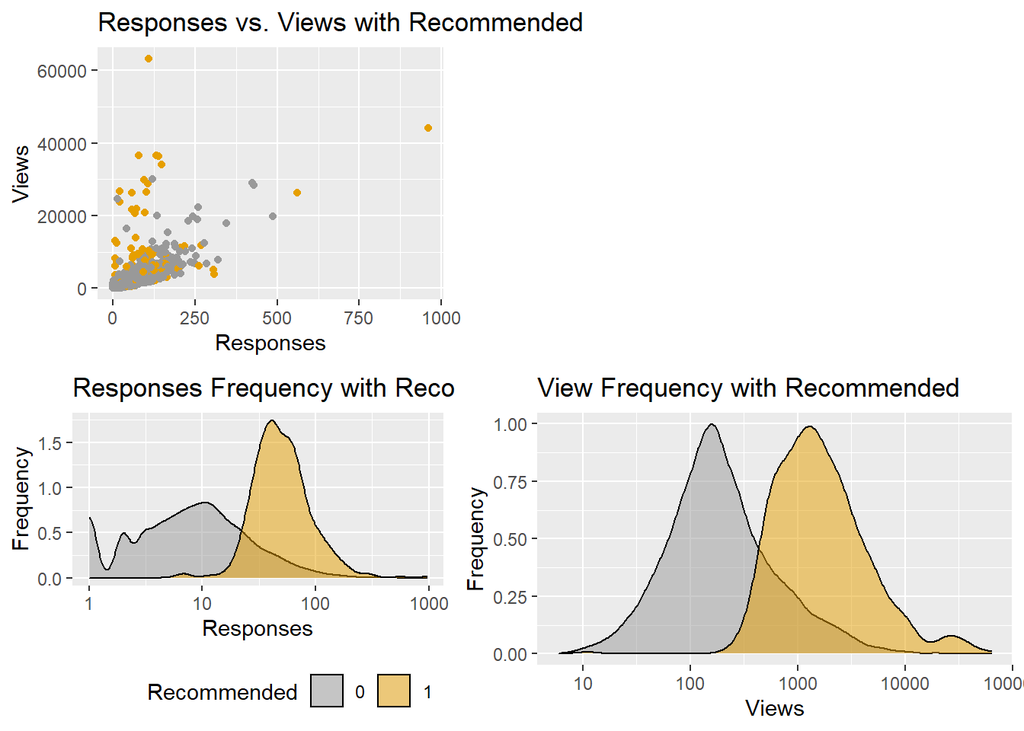

```r
plot_4 <- ggplot(suggestions,aes(x = Responses, y = Views, color = as.factor(Recommended))) +
  geom_point() +
  scale_color_manual(values = c('#999999','#E69F00')) +
  labs(title = "Responses vs. Views with Recommended", y = "Views", x = "Responses")+
  theme(legend.position = "none")


plot_5 <- ggplot(suggestions, aes(x = Responses, fill = as.factor(Recommended))) +
  geom_density(alpha=.5) +
  scale_fill_manual(values = c('#999999','#E69F00')) +
  scale_x_log10()+
  labs(fill='Recommended')+
  labs(title = "Responses Frequency with Recommended", y = "Frequency", x = "Responses")+
  scale_fill_manual(values = c('#999999','#E69F00')) +
  theme(legend.position = "bottom",
    legend.justification = c("right", "top"),
    legend.box.just = "right")
plot_6 <- ggplot(suggestions, aes( x = Views, fill = as.factor(Recommended))) +
  geom_density(alpha=.5) +
  scale_fill_manual(values = c('#999999','#E69F00')) +
  labs(title = "View Frequency with Recommended", y = "Frequency", x = "Views")+
  scale_x_log10()+
  theme(legend.position = "none")



blankPlot_1 <- ggplot()+geom_blank(aes(1,1))+
  theme(plot.background = element_blank(),
   panel.grid.major = element_blank(),
   panel.grid.minor = element_blank(),
   panel.border = element_blank(),
   panel.background = element_blank(),
   axis.title.x = element_blank(),
   axis.title.y = element_blank(),
   axis.text.x = element_blank(),
   axis.text.y = element_blank(),
   axis.ticks = element_blank()
     )


grid.arrange(plot_4, blankPlot_1, plot_5, plot_6,
        ncol=2, nrow=2, widths=c(4, 5), heights=c(4, 4))
```

-*Based on “Responses” density plot, with recommended is a normal distribution., which is better than without recommended. On the other hand, based on “Vies” density plot, both with recommended and without recommended are normal distribution.*

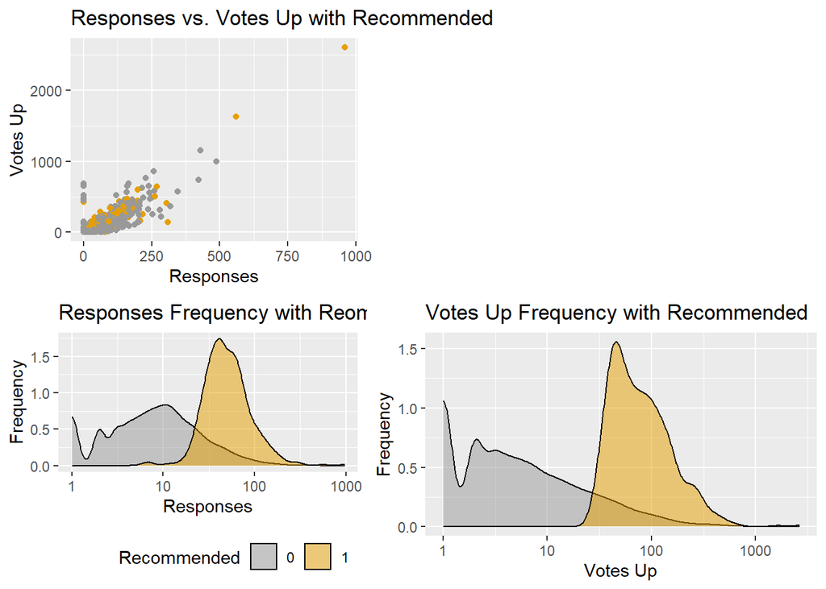

```r
plot_7 <- ggplot(suggestions,aes(x = Responses, y = Votes_Up, color = as.factor(Recommended))) +
  geom_point() +
  labs(title = "Responses vs. Votes Up with Recommended", y = "Votes Up", x = "Responses")+
  scale_color_manual(values = c('#999999','#E69F00')) +
  theme(legend.position = "none")


plot_8 <- ggplot(suggestions, aes(x = Responses, fill = as.factor(Recommended))) +
  geom_density(alpha=.5) +
  scale_fill_manual(values = c('#999999','#E69F00')) +
  scale_x_log10()+
  labs(fill='Recommended')+
  labs(title = "Responses Frequency with Reommended", y = "Frequency", x = "Responses")+
  scale_fill_manual(values = c('#999999','#E69F00')) +
  theme(legend.position = "bottom",
    legend.justification = c("right", "top"),
    legend.box.just = "right")
plot_9 <- ggplot(suggestions, aes( x = Votes_Up, fill = as.factor(Recommended))) +
  geom_density(alpha=.5) +
  scale_fill_manual(values = c('#999999','#E69F00')) +
  labs(title = "Votes Up Frequency with Recommended", y = "Frequency", x = "Votes Up")+
  scale_x_log10()+
  theme(legend.position = "none")



blankPlot_2 <- ggplot()+geom_blank(aes(1,1))+
  theme(plot.background = element_blank(),
   panel.grid.major = element_blank(),
   panel.grid.minor = element_blank(),
   panel.border = element_blank(),
   panel.background = element_blank(),
   axis.title.x = element_blank(),
   axis.title.y = element_blank(),
   axis.text.x = element_blank(),
   axis.text.y = element_blank(),
   axis.ticks = element_blank()
     )


grid.arrange(plot_7, blankPlot_2, plot_8, plot_9,
        ncol=2, nrow=2, widths=c(4, 5), heights=c(4, 4))
```

-*Based on “Responses” density plot, with recommended is a normal distribution., which is better than without recommended. On the other hand, based on “Votes_up” density plot, with recommended seems like normal distribution, but without recommended is skewed right distribution.*

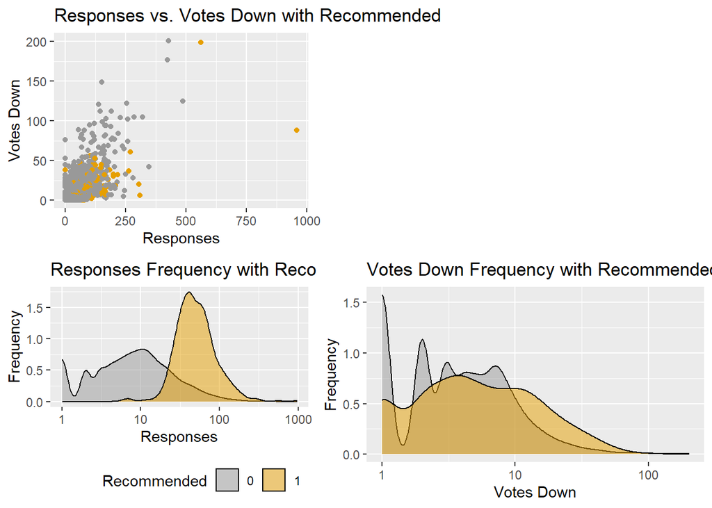

```r
plot_10 <- ggplot(suggestions,aes(x = Responses, y = Votes_Down, color = as.factor(Recommended))) +
  geom_point() +
  labs(title = "Responses vs. Votes Down with Recommended", y = "Votes Down", x = "Responses")+
  scale_color_manual(values = c('#999999','#E69F00')) +
  theme(legend.position = "none")


plot_11 <- ggplot(suggestions, aes(x = Responses, fill = as.factor(Recommended))) +
  geom_density(alpha=.5) +
  scale_fill_manual(values = c('#999999','#E69F00')) +
  scale_x_log10()+
  labs(fill='Recommended')+
  labs(title = "Responses Frequency with Recommended", y = "Frequency", x = "Responses")+
  scale_fill_manual(values = c('#999999','#E69F00')) +
  theme(legend.position = "bottom",
    legend.justification = c("right", "top"),
    legend.box.just = "right")
plot_12 <- ggplot(suggestions, aes(x = Votes_Down, fill = as.factor(Recommended))) +
  geom_density(alpha=.5) +
  scale_fill_manual(values = c('#999999','#E69F00')) +
  labs(title = "Votes Down Frequency with Recommended", y = "Frequency", x = "Votes Down")+
  scale_x_log10()+
  theme(legend.position = "none")



blankPlot_3 <- ggplot()+geom_blank(aes(1,1))+
  theme(plot.background = element_blank(),
   panel.grid.major = element_blank(),
   panel.grid.minor = element_blank(),
   panel.border = element_blank(),
   panel.background = element_blank(),
   axis.title.x = element_blank(),
   axis.title.y = element_blank(),
   axis.text.x = element_blank(),
   axis.text.y = element_blank(),
   axis.ticks = element_blank()
     )


grid.arrange(plot_10, blankPlot_3, plot_11, plot_12,
        ncol=2, nrow=2, widths=c(4, 5), heights=c(4, 4))
```

-*Based on “Responses” density plot, with recommended is a normal distribution., which is better than without recommended. On the other hand, based on “Votes_down” density plot, both with recommended and without recommend are seems to skewed right distribution.*

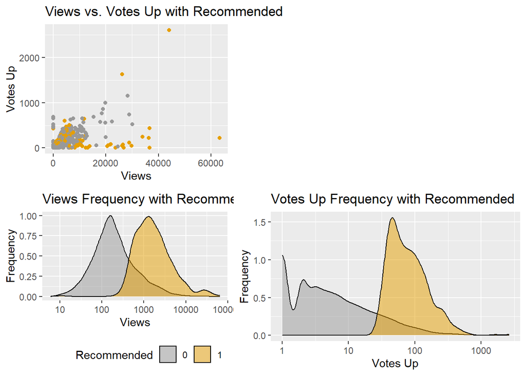

```r
plot_13 <- ggplot(suggestions,aes(x = Views, y = Votes_Up, color = as.factor(Recommended))) +
  geom_point() +
  labs(title = "Views vs. Votes Up with Recommended", y = "Votes Up", x = "Views")+
  scale_color_manual(values = c('#999999','#E69F00')) +
  theme(legend.position = "none")


plot_14 <- ggplot(suggestions, aes(x = Views, fill = as.factor(Recommended))) +
  geom_density(alpha=.5) +
  scale_fill_manual(values = c('#999999','#E69F00')) +
  scale_x_log10()+
  labs(fill='Recommended')+
  labs(title = "Views Frequency with Recommended", y = "Frequency", x = "Views")+
  scale_fill_manual(values = c('#999999','#E69F00')) +
  theme(legend.position = "bottom",
    legend.justification = c("right", "top"),
    legend.box.just = "right")
plot_15 <- ggplot(suggestions, aes(x = Votes_Up, fill = as.factor(Recommended))) +
  scale_x_log10()+
  geom_density(alpha=.5) +
  labs(title = "Votes Up Frequency with Recommended", y = "Frequency", x = "Votes Up")+
  scale_fill_manual(values = c('#999999','#E69F00')) +
  theme(legend.position = "none")


blankPlot_4 <- ggplot()+geom_blank(aes(1,1))+
  theme(plot.background = element_blank(),
   panel.grid.major = element_blank(),
   panel.grid.minor = element_blank(),
   panel.border = element_blank(),
   panel.background = element_blank(),
   axis.title.x = element_blank(),
   axis.title.y = element_blank(),
   axis.text.x = element_blank(),
   axis.text.y = element_blank(),
   axis.ticks = element_blank()
     )


grid.arrange(plot_13, blankPlot_3, plot_14, plot_15,
        ncol=2, nrow=2, widths=c(4, 5), heights=c(4, 4))
```

-*Based on “Views” density plot, both recommended and without recommend are normal distribution. On the other hand, based on “Votes_up” density plot, with recommended seems like normal distribution, but without recommended is skewed right distribution..*

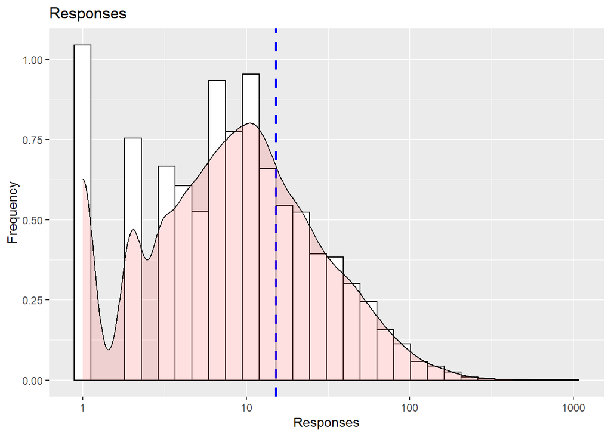

```r
Resp <-
  ggplot(suggestions, aes(x = Responses)) +
  geom_histogram(aes(y=..density..), colour="black", fill="white")+
  scale_x_log10()+
  geom_vline(aes(xintercept = mean(Responses)), color = "blue", linetype = "dashed", size = 1)+
  labs(title = "Responses", y = "Frequency", x = "Responses")+
  geom_density(alpha=.2, fill="#FF6666")

Resp
```

-*The plot above illustrates that the `Responses` variable has a right skewed distribution, which means the mean is greater than median.*

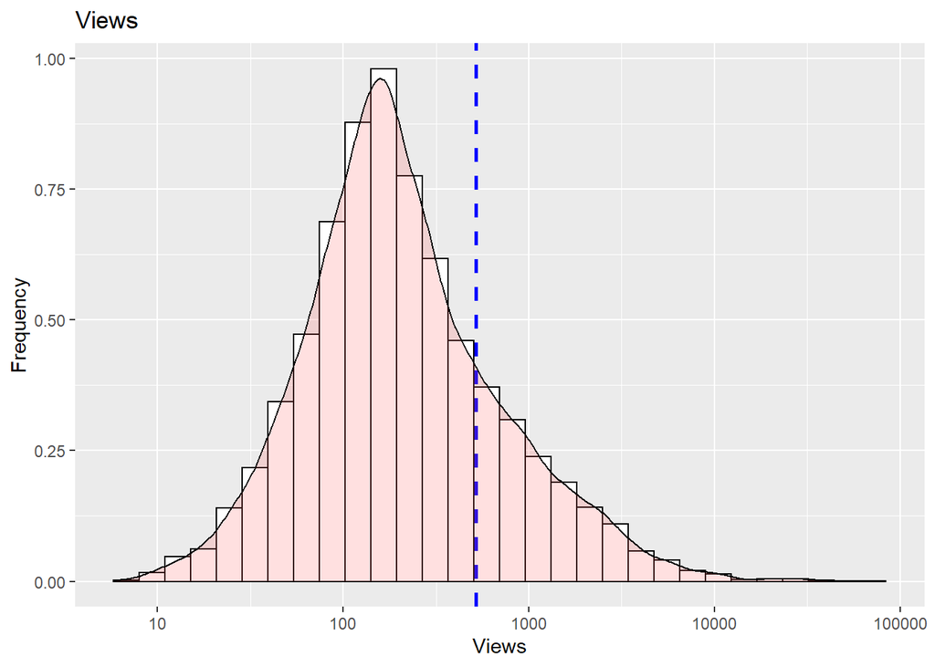

```r
Plot_Views <-
  ggplot(suggestions, aes(x = Views)) +
  geom_histogram(aes(y=..density..), colour="black", fill="white")+
  scale_x_log10()+
  geom_vline(aes(xintercept = mean(Views)), color = "blue", linetype = "dashed", size = 1)+
  labs(title = "Views", y = "Frequency", x = "Views")+
  geom_density(alpha=.2, fill="#FF6666")

Plot_Views
```

```r
summary(suggestions$Views)
```

```
##    Min. 1st Qu.  Median    Mean 3rd Qu.    Max.
##     0.0    94.0   180.0   520.5   409.0 63243.0
```

–*The plot above illustrates that the `Views` variable seems like normal distribution, but based on statistics summary the mean is larger tahn median, which means it is right skewed.*

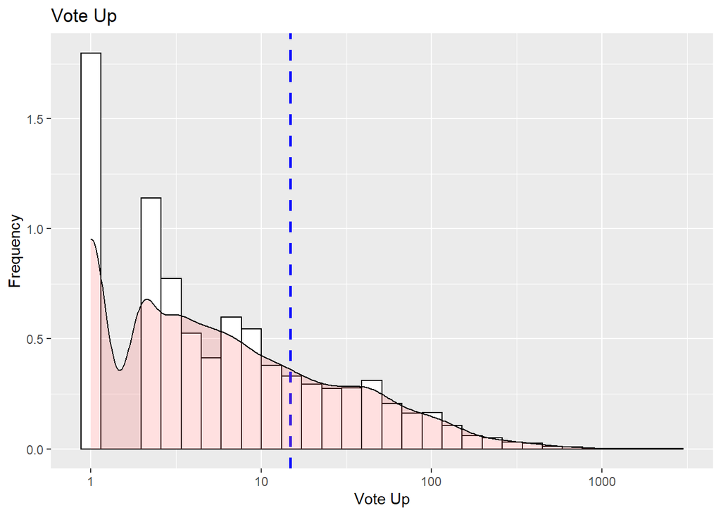

```r
Plot_Vote_up <-
  ggplot(suggestions, aes(x = Votes_Up)) +
  geom_histogram(aes(y=..density..), colour="black", fill="white")+
  scale_x_log10()+
  geom_vline(aes(xintercept = mean(Votes_Up)), color = "blue", linetype = "dashed", size = 1)+
  labs(title = "Vote Up", y = "Frequency", x = "Vote Up")+
  geom_density(alpha=.2, fill="#FF6666")

Plot_Vote_up
```

- *The plot above illustrates that the `Votes_Up` variable has an extremely right skewed distribution, which means the mean is greater than median. This also shows that many posts were not voted up.*

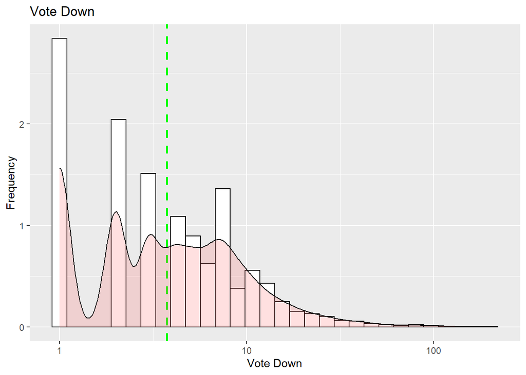

```r
Plot_Vote_down <-
  ggplot(suggestions, aes(x = Votes_Down)) +
  geom_histogram(aes(y=..density..), colour="black", fill="white")+
  geom_vline(aes(xintercept = mean(Votes_Down)), color = "green", linetype = "dashed", size = 1)+
  labs(title = "Vote Down", y = "Frequency", x = "Vote Down")+
  scale_x_log10()+
  geom_density(alpha=.2, fill="#FF6666")

Plot_Vote_down
```

– *The plot above illustrates that the `Votes_Down` variable has a right skewed distribution, which means the mean is greater than median. This also shows that most posts were not voted down very often. In combination with the previous plot, this may indicate than the vote up and vote down feature is not utilized very often.*

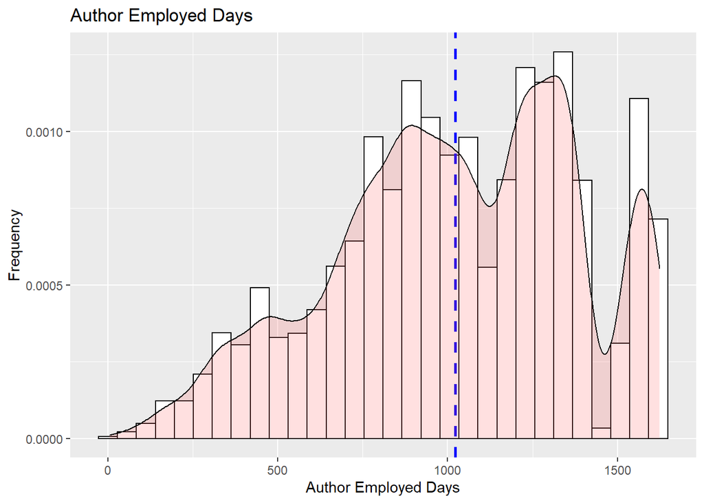

```r
plot_emplyd_days <-
  ggplot(suggestions, aes(x = Author_emplyd_days)) +
  geom_histogram(aes(y=..density..), colour="black", fill="white")+
  geom_vline(aes(xintercept = mean(Author_emplyd_days)), color = "blue", linetype = "dashed", size = 1)+
  labs(title = "Author Employed Days", y = "Frequency", x = "Author Employed Days")+
  geom_density(alpha = 0.2, fill="#FF6666")

plot_emplyd_days
```

```r
summary(suggestions$Author_emplyd_days)
```

```
##    Min. 1st Qu.  Median    Mean 3rd Qu.    Max.
##       4     774    1035    1022    1298    1624
```

- *The histogram produced on `Author_emplyd_days` makes it hard to determine if it has normal distribution or not, so we need to use the “Summary” to perform this variable basic statistic. Thus, we can see that median is slightly larger than mean, which is left skewed. We can also see that there is a wide range in terms of how long employees have been with the company.*

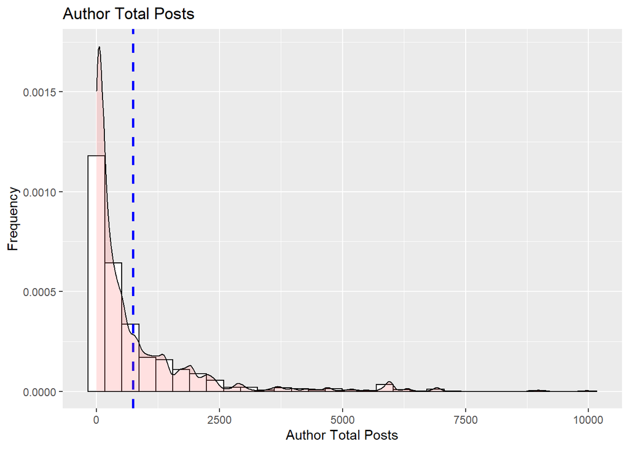

```r
Plot_auth_posts <-
  ggplot(suggestions, aes(x = Author_TotalPosts)) +
  geom_histogram(aes(y=..density..), colour="black", fill="white")+
  geom_vline(aes(xintercept = mean(Author_TotalPosts)), color = "blue", linetype = "dashed", size = 1)+
  labs(title = "Author Total Posts", y = "Frequency", x = "Author Total Posts")+
  geom_density(alpha=.2, fill="#FF6666")

Plot_auth_posts
```

```r
summary(suggestions$Author_TotalPosts)
```

```
##    Min. 1st Qu.  Median    Mean 3rd Qu.    Max.
##     1.0    57.0   286.0   746.5   909.0  9992.0
```

-*The plot above illustrates that the `Author_TotalPosts` variable has a right skewed distribution, which means the mean is greater than median. Compared to the other variables, we can see a wider distribution for this variable.*

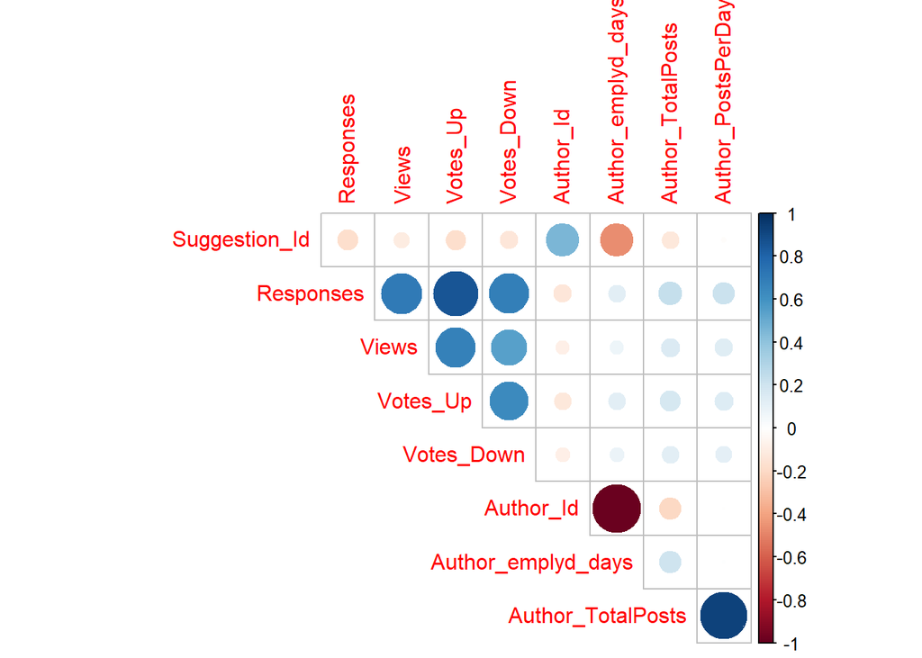

```r
library(corrplot)
df_1 <- select(suggestions, -Recommended)

correlations <- cor(df_1, use = "pairwise.complete.obs")

corrplot(correlations, diag = FALSE, type = "upper", t1.cex = 0.6)
```

```r
# Number of Distinct Authohr_Id

Distinct_Author<-
suggestions %>%
  group_by(Author_Id) %>%
  summarise(count=n()) %>%
  arrange(desc(count))

print(Distinct_Author)
```

```
## # A tibble: 4,692 x 2
##    Author_Id count
##        <int> <int>
##  1    292847   197
##  2    394835   159
##  3    478933   120
##  4    312685   108
##  5    992971    85
##  6    550387    77
##  7     36710    75
##  8    845514    73
##  9   1143837    70
## 10    905707    69
## # ... with 4,682 more rows
```

-*The table above indicates that `Author_ID` `292847` has generated the most amount of suggestions.*

```r
rankings <- table(suggestions$Author_Id, suggestions$Recommended)
rankings <- data.frame(unclass(rankings))
rankings <- rename(rankings, not_rec = X0)
rankings <- rename(rankings, rec = X1)
rankings$total_sug <- with(rankings, not_rec + rec)
rankings$frac_rec <- with(rankings, rec / total_sug)

rankings <- rankings[order(-rankings$frac_rec, -rankings$rec), ]
head(rankings,20)
```

```
##         not_rec rec total_sug  frac_rec
## 268571        0   3         3 1.0000000
## 206577        0   2         2 1.0000000
## 1764          0   1         1 1.0000000
## 47044         0   1         1 1.0000000
## 50389         0   1         1 1.0000000
## 75427         0   1         1 1.0000000
## 144806        0   1         1 1.0000000
## 274939        0   1         1 1.0000000
## 294532        0   1         1 1.0000000
## 310661        0   1         1 1.0000000
## 413317        0   1         1 1.0000000
## 418180        0   1         1 1.0000000
## 493296        0   1         1 1.0000000
## 532759        0   1         1 1.0000000
## 597820        0   1         1 1.0000000
## 647117        0   1         1 1.0000000
## 686450        0   1         1 1.0000000
## 885075        0   1         1 1.0000000
## 1430893       0   1         1 1.0000000
## 202713        1   2         3 0.6666667
```

-*The table above ranks all `Author_ID`s by the fraction of every Author’s suggestions that were recommended. We calculated this by dividing the amount of recommended suggestions every author had by the amount of total suggestions that author made. The table is sorted to show the`Author_ID`’s with the highest fraction of recommended suggestions. If any `Author_ID`s have the same rate, the table is then sorted to show the `Author_ID` with the highest total number of suggestions first. This table is insightful as it shows which employees have a better rankings, and which employees are more likely to make good suggestions. This is more insightful than the previous table above, because even though an employee makes a lot of suggestions, that does not mean they are quality suggestions. This table, resolves that to rank employees on the quality of their suggestions rather than the quantity of suggestions.*

-*These rankings can identify groups of employees whose suggestions could be aggregated to provide more reliable suggestions than made by the best individuals. These groups can be created by any metric we have access to.*

*Please note that we choose to only show the top 20 `Author_ID`s, however the table has all `Author_ID`s.*

```r
# Perform the proportion of with recommended and without recommended

sug_freq <-
  suggestions %>%
    group_by(Recommended) %>%
    summarise(n = n()) %>%
    mutate(Freq = n/sum(n))

print(sug_freq)
```

```
## # A tibble: 2 x 3
##   Recommended     n   Freq
##         <int> <int>  <dbl>
## 1           0 15867 0.966
## 2           1   562 0.0342
```

-*It obvious that without recommended has larger proportion than with Recommended.*

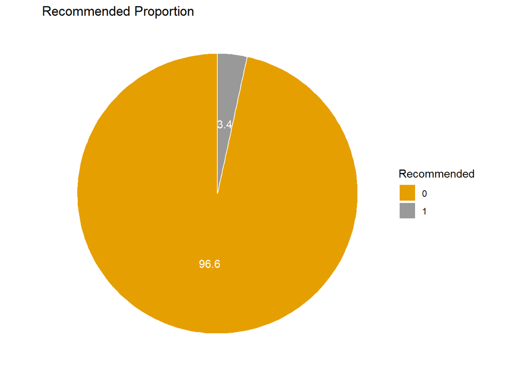

```r
recomm_data <- suggestions %>%
  count(Recommended) %>%
  arrange(desc(Recommended)) %>%
  mutate(prop = round(n*100/sum(n), 1),
         lab.ypos = cumsum(prop) - 0.5*prop)

mycols1 <- c("#E69F00", "#999999")

recomm_1 <-
  ggplot(recomm_data, aes(x = "", y = prop, fill = as.factor(Recommended))) +
  geom_bar(width = 1, stat = "identity", color = "white") +
  coord_polar("y", start = 0)+
  geom_text(aes(y = lab.ypos, label = prop), color = "white")+
  scale_fill_manual(values = mycols1) +
  theme_void()+
  labs(title = "Recommended Proportion", fill = "Recommended")

recomm_1
```

-*The pie chart illustrates how extremely imbalanced our data set is.*

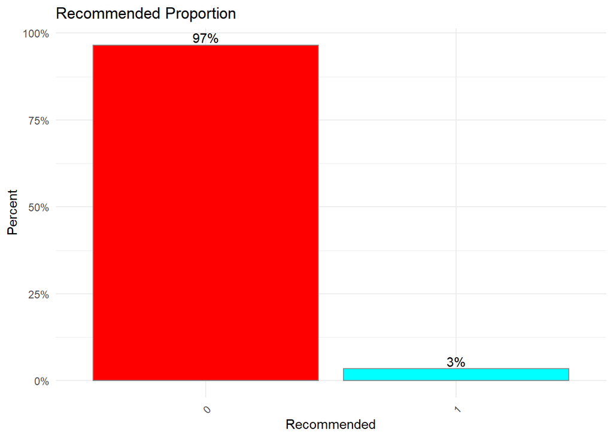

```r
Recomm_data_2 <-
  suggestions %>%
  count(Recommended) %>%
  mutate(pct = n / sum(n),
         pctlabel = paste0(round(pct*100), "%"))

recomm_2 <-
  ggplot(Recomm_data_2,
       aes(x = reorder(Recommended, -pct),
           y = pct)) +
  geom_bar(stat = "identity",
           fill = rainbow(2),
           color = "azure4") +
  geom_text(aes(label = pctlabel),
            vjust = -0.25) +
  scale_y_continuous(labels = scales::percent) +
  theme_minimal() +
  labs(x = "Recommended",
       y = "Percent",
       title  = "Recommended Proportion")+
  theme(axis.text.x = element_text(angle = 45, hjust = 1))

recomm_2
```

-*Specifically, only 3% of our data set contains recommended suggestions.*

### Training and Testing

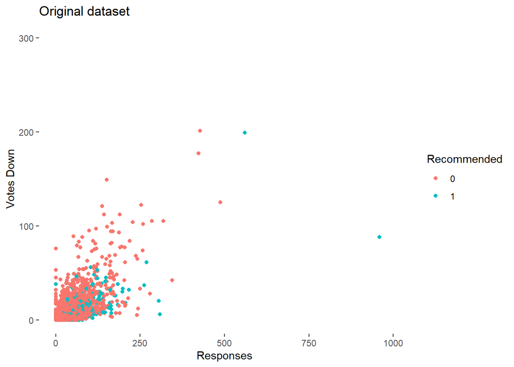

```r
ggplot(data = suggestions, aes(x = Responses, y = Votes_Down, colour = as.factor(Recommended)))+
  geom_point()+
  labs(x = "Responses", y = "Votes Down", colour = "Recommended")+
    ggtitle("Original dataset")+
    xlab("Responses")+
    ylab("Votes Down")+
    geom_point() +
    xlim(0, 1000)+
    ylim(0, 300)+
    theme(panel.grid.major = element_blank(),
          panel.grid.minor = element_blank(),
          panel.background = element_blank(),
          legend.key=element_blank())
```

-*Based on our original data set, it obviously the data set is unbalance, so we need to use oversampling or under-sampling to deal with unbalance data set.*

-*We will use over-sampling to deal with unbalanced data set because we found out our minority class (1) has a very small proportion against the majority class. The random oversampling involves randomly duplicating examples from the minority class and adding them to the training data set. Moreover, we set the proportion (p) = 0.4 because we do not want to be very fairly same as the majority, if they are the same, then it will cause over-fitting, so we need to be 60% for a majority and 40% for minority or the opposite one.*

## Adressing the Unbalanced data set

##### Below we address our imbalanced dataset. This method resamples the recommended suggestions to ensure that there is a relatively balanced porportion of recommended and non-recommended suggestions.

```r
suggestions_new <- ovun.sample(Recommended ~ ., data = suggestions, method = "over", p = 0.4,  seed = 1)$data

table(suggestions_new$Recommended)
```

```
##
##     0     1
## 15867 10521
```

```r
## Without unique value: Suggestions ID, Author Id

df_1 <- suggestions_new %>%
  dplyr::select(-c("Suggestion_Id", "Author_Id"))


samp <- floor(0.80*nrow(suggestions_new))
train_ind <- sample(1:(nrow(suggestions_new)), size = samp)

train <- df_1[train_ind, ]
test  <- df_1[-train_ind, ]
```

```r
table(train$Recommended)
```

```
##
##     0     1
## 12730  8380
```

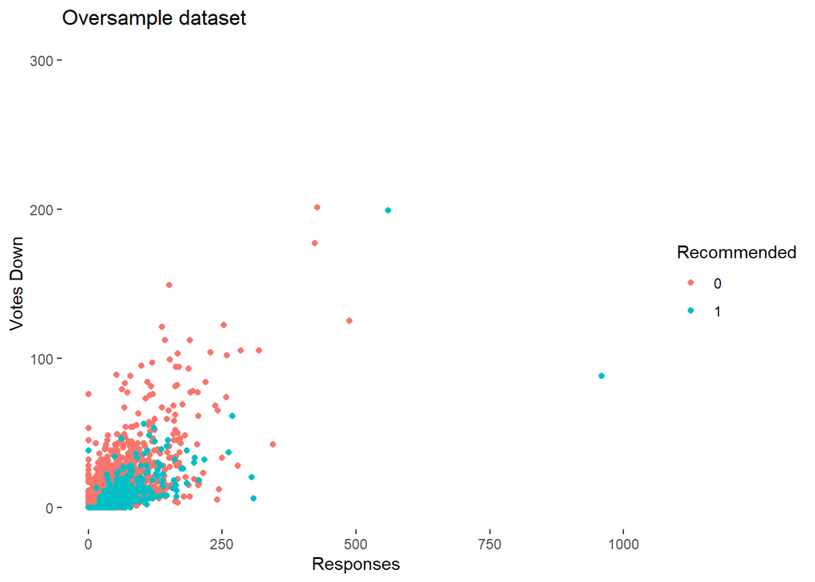

```r
ggplot(data = suggestions_new, aes(x = Responses, y = Votes_Down, colour = as.factor(Recommended)))+
  geom_point()+
  labs(x = "Responses", y = "Votes Down", colour = "Recommended")+
    ggtitle("Oversample dataset")+
    xlab("Responses")+
    ylab("Votes Down")+
    geom_point() +
    xlim(0, 1000)+
    ylim(0, 300)+
    theme(panel.grid.major = element_blank(),
          panel.grid.minor = element_blank(),
          panel.background = element_blank(),
          legend.key=element_blank())
```

-*After the over-sampling method, it seems like the data set is more balanced now*

## Model Selection and Self-Comparison

### Logistic Regression

```r
glm.mod<-glm(Recommended~ ., data = train,
                family = binomial)
kable(coef(summary(glm.mod)),digits = c(3, 3, 3, 4))
```

|  | Estimate | Std. Error | z value | Pr(>\|z\|) |
| --- | --- | --- | --- | --- |
| (Intercept) | -3.429 | 0.113 | -30.288 | 0.0000 |
| Responses | 0.032 | 0.002 | 16.116 | 0.0000 |
| Views | 0.000 | 0.000 | 11.170 | 0.0000 |
| Votes_Up | 0.055 | 0.001 | 39.422 | 0.0000 |
| Votes_Down | -0.275 | 0.006 | -44.738 | 0.0000 |
| Author_emplyd_days | 0.000 | 0.000 | 4.182 | 0.0000 |
| Author_TotalPosts | 0.000 | 0.000 | 4.215 | 0.0000 |
| Author_PostsPerDay | 0.133 | 0.057 | 2.334 | 0.0196 |

-*In logistic regression, all variables are significant, which means they are statistically significant. Thus, we need to do variance inflation factor to see the Multi-Collinearity in our model.*

-*Variance Inflation Factor (VIF) means how much the variance is inflated. In machine learning, it is used to detected presence of multi-collinearity varaince inflation factor (VIF) measure how much the variance of the estimated regression coefficients are inflated as compared to when the predictor variables are not linearly related*

-*As a thumb rule, any variable with VIF > 1.5 is avoided in a regression analysis. Sometimes the condition is relaxed to 2, instead of 1.5. In our case, if the VIF is larger than 5, we need to remove it to avoid the multi-collinearity in the regression model*

```r
vif(glm.mod)
```

```
##          Responses              Views           Votes_Up         Votes_Down
##           3.253774           1.304881           3.850287           2.475440
## Author_emplyd_days  Author_TotalPosts Author_PostsPerDay
##           1.676134          12.977875          12.471621
```

-**“Author_TotalPosts”, and “Author_PostsPerday” are higher than 5,which means they are highly correlated. Thus, we need to remove these variables and re-fit our logistic model.***

```r
glm.mod.new<-glm(Recommended~. - Author_TotalPosts - Author_PostsPerDay, data = train, family = binomial)
kable(coef(summary(glm.mod.new)),digits = c(3, 3, 3, 4))
```

|  | Estimate | Std. Error | z value | Pr(>\|z\|) |
| --- | --- | --- | --- | --- |
| (Intercept) | -3.358 | 0.091 | -37.077 | 0 |
| Responses | 0.036 | 0.002 | 18.426 | 0 |
| Views | 0.000 | 0.000 | 11.496 | 0 |
| Votes_Up | 0.058 | 0.001 | 41.050 | 0 |
| Votes_Down | -0.294 | 0.006 | -47.220 | 0 |
| Author_emplyd_days | 0.001 | 0.000 | 8.779 | 0 |

-*All independent variables are statistically significant, which means p-value is smaller 0.05, but we need to check again the VIF*

```r
vif(glm.mod.new)
```

```
##          Responses              Views           Votes_Up         Votes_Down
##           3.167580           1.306848           3.861420           2.488640
## Author_emplyd_days
##           1.007780
```

-*Great, all the VIF value is smaller than 5, which are moderately correlated. Thus, we can use the re-fit logistic model to do confusion matrix and prediction*

```r
anova(glm.mod.new, test = "Chisq")
```

```
## Analysis of Deviance Table
##
## Model: binomial, link: logit
##
## Response: Recommended
##
## Terms added sequentially (first to last)
##
##
##                    Df Deviance Resid. Df Resid. Dev  Pr(>Chi)
## NULL                               21109      28362
## Responses           1  10999.2     21108      17363 < 2.2e-16 ***
## Views               1    176.5     21107      17186 < 2.2e-16 ***
## Votes_Up            1   1636.2     21106      15550 < 2.2e-16 ***
## Votes_Down          1   3445.0     21105      12105 < 2.2e-16 ***
## Author_emplyd_days  1     75.5     21104      12030 < 2.2e-16 ***
## ---
## Signif. codes:  0 '***' 0.001 '**' 0.01 '*' 0.05 '.' 0.1 ' ' 1
```

-*Above the Anova test table, all the variables of Chi-square p-value are smaller than 0.05, which means that this new model provides a better fit*

```r
list(new_model = pscl::pR2(glm.mod.new)["McFadden"])
```

```
## fitting null model for pseudo-r2
```

```
## $new_model
##  McFadden
## 0.5758558
```

-*Unlike R-Squared in linear regression, the model rarely achieve a high McFadden R-squared. In fact, in McFadden’s own words model with McFadden pseudo R-squared roughly equal to 0.4 represents a very good fit. In our case, the McFadden’s pseudo R-squared is 0.575, which is a good fit in our data set.*

##### Residual Assessment

-*Logistic regression does not assume the residuals are normally distributed nor that the variance is constant. But, the deviance residual is useful for determining if individual points are not well fit by the model. Here we can fit the standardized deviance residuals to see how many exceed 3 standard deviations*

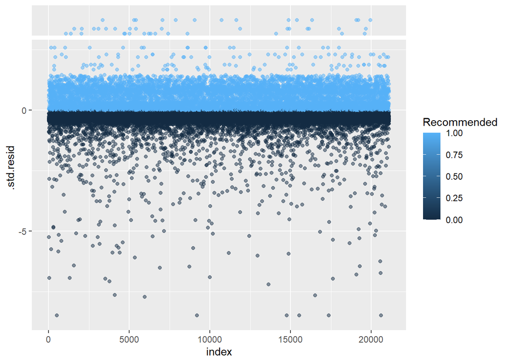

```r
glm_new <- augment(glm.mod.new) %>%
  mutate(index = 1:n())

ggplot(glm_new, aes(index, .std.resid, color = Recommended)) +
  geom_point(alpha = .5) +
  geom_ref_line(h = 3)
```

-*Those standardized residuals that exceed 3 represent possible outliers and may deserve closer attention. So, we can filter for theses residuals to get a closer look.*

```r
glm_new %>%
  filter(abs(.std.resid) > 3)
```

```
## # A tibble: 197 x 16
##    .rownames Recommended Responses Views Votes_Up Votes_Down Author_emplyd_days
##    <chr>           <int>     <int> <int>    <int>      <int>              <int>
##  1 743                 0       120  5517      247         12               1098
##  2 48                  0       162  4585      361          4               1226
##  3 4157                0       120 30072      519         76               1619
##  4 1589                0        91  2180      167         21               1615
##  5 5763                0        57  3231      208          2               1176
##  6 659                 0       146 10779      416         59               1061
##  7 64                  0       244  6921      473         12               1237
##  8 31                  0       148  3639      419         37               1352
##  9 1                   0        77  3849      242          7               1615
## 10 2678                0        96  3220      252          6               1362
## # ... with 187 more rows, and 9 more variables: Author_TotalPosts <int>,
## #   Author_PostsPerDay <dbl>, .fitted <dbl>, .resid <dbl>, .std.resid <dbl>,
## #   .hat <dbl>, .sigma <dbl>, .cooksd <dbl>, index <int>
```

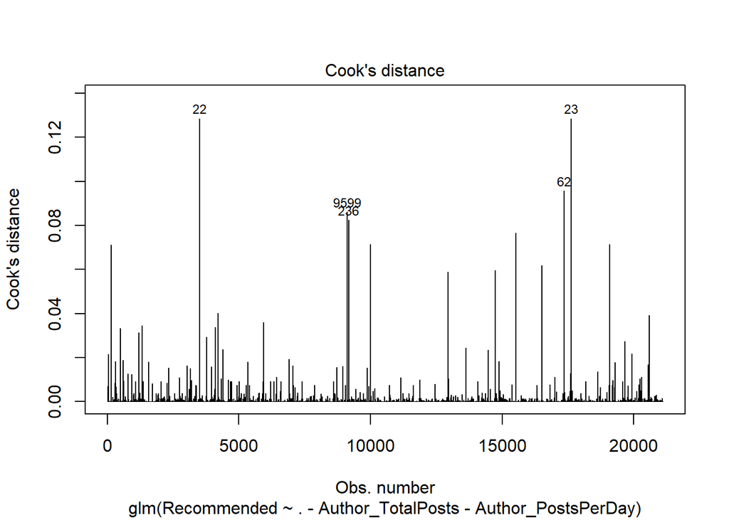

```r
plot(glm.mod.new, which = 4, id.n = 5)
```

-*Similar to logistic regression can also identify influential observations with Cook’s distance values. Here we identify the top 5 largest values.*

-*We can investigate these further as well: those suggestions which are without “Author_TotalPosts” and “Author_posts”*

```r
glm_new %>%
  top_n(5, .cooksd)
```

```
## # A tibble: 5 x 16
##   .rownames Recommended Responses Views Votes_Up Votes_Down Author_emplyd_days
##   <chr>           <int>     <int> <int>    <int>      <int>              <int>
## 1 22                  0         0     0      688         45               1559
## 2 9599                0       423 28940      742        177               1335
## 3 236                 0       487 19867      999        125               1332
## 4 62                  0       258 18916      860         74               1336
## 5 23                  0         0     0      688         45               1559
## # ... with 9 more variables: Author_TotalPosts <int>, Author_PostsPerDay <dbl>,
## #   .fitted <dbl>, .resid <dbl>, .std.resid <dbl>, .hat <dbl>, .sigma <dbl>,
## #   .cooksd <dbl>, index <int>
```

-*Those suggestions that were not recommended, there are two responses very low which are 0.*

##### Training Data Set

```r
pred_rec_train <- predict.glm(glm.mod.new, data = train, type="response")

a <- pred_rec_train > 0.5

a <- ifelse(a == "TRUE", 1, 0)

cfm_glm_rec_train <- confusionMatrix(as.factor(a), as.factor(train$Recommended))
cfm_glm_rec_train
```

```
## Confusion Matrix and Statistics
##
##           Reference
## Prediction     0     1
##          0 12036   731
##          1   694  7649
##
##                Accuracy : 0.9325
##                  95% CI : (0.929, 0.9358)
##     No Information Rate : 0.603
##     P-Value [Acc > NIR] : <2e-16
##
##                   Kappa : 0.8589
##
##  Mcnemar's Test P-Value : 0.3403
##
##             Sensitivity : 0.9455
##             Specificity : 0.9128
##          Pos Pred Value : 0.9427
##          Neg Pred Value : 0.9168
##              Prevalence : 0.6030
##          Detection Rate : 0.5702
##    Detection Prevalence : 0.6048
##       Balanced Accuracy : 0.9291
##
##        'Positive' Class : 0
##
```

```r
# misclas rate
lr_mcr_train <-(round(mean(a != train$Recommended),4)*100)
lr_mcr_train
```

```
## [1] 6.75
```

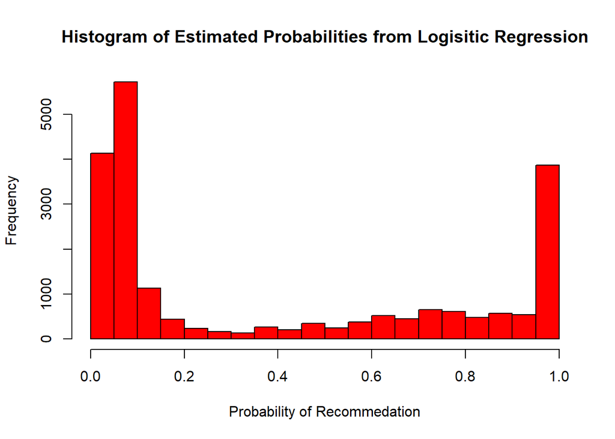

```r
hist(glm.mod.new$fitted.values, xlab = "Probability of Recommedation", col = "red", main = "Histogram of Estimated Probabilities from Logisitic Regression")
```

- *The mis-classifcation rate for logistic regression of training data set is 6.75.*

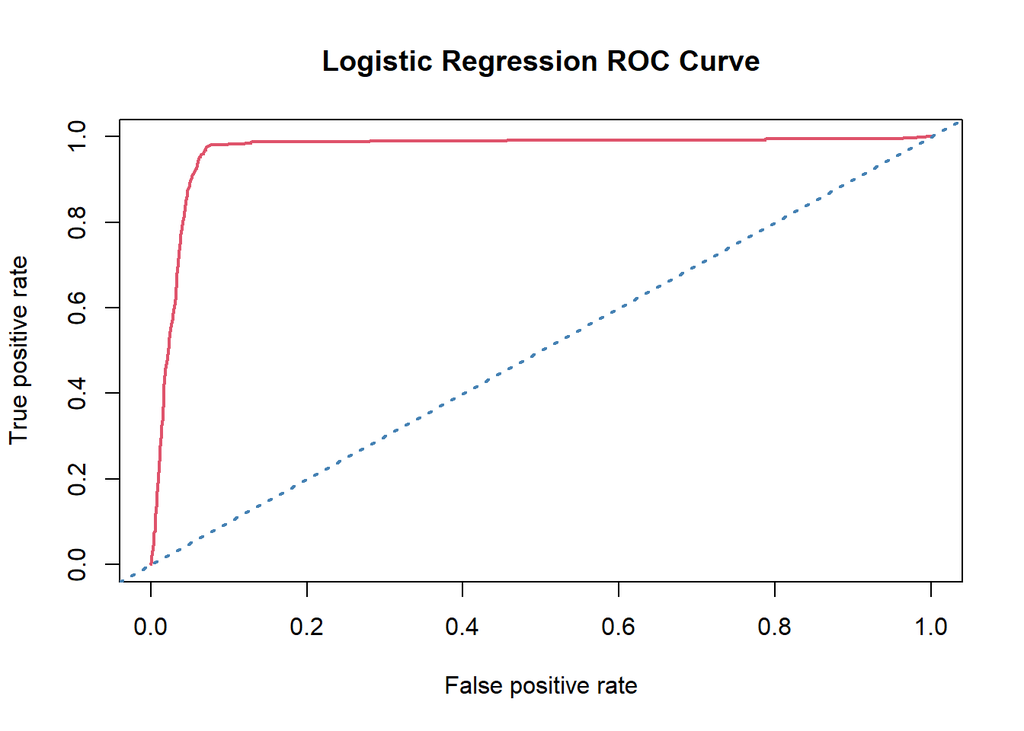

```r
pred_1 <- predict.glm(glm.mod.new, train, type="response")

prediction_1 <- prediction(pred_1, train$Recommended)

performance_1 <-ROCR::performance(prediction_1, "tpr","fpr")

LOG_ROC <- plot(performance_1,main = "Logistic Regression ROC Curve",col = 2,lwd = 2)
abline(a = 0,b = 1,lwd = 2,lty = 3,col = "steelblue")
```

```r
LOG_ROC
```

```r
AUC_1 <- unlist(slot(ROCR::performance(prediction_1, "auc"), "y.values"))

AUC_1
```

```
## [1] 0.9657395
```

-*Based on the Logistic Regression, AUC is 0.96, which means it is higher then the threshold (0.5) and also it reflects that this model doing very well in classification data set. Thus, this might be a good model can use to predict our data set.*

-*Lift Curve can help us evaluate our mod: in our example, we want to estimate that to provide a way for employees to give suggestions to the upper management about a variety of topics.*

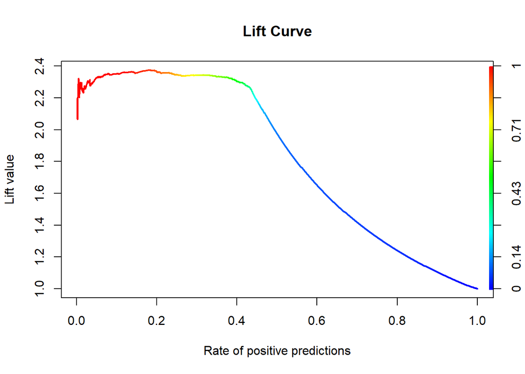

```r
perf_log_lift <- ROCR::performance(prediction_1, "lift", "rpp")

plot(perf_log_lift, main = "Lift Curve", col = 2, lwd = 2, colorize=TRUE)
```

##### Look at one varible at a time

```r
simp_glm_views = glm(data = train,
                            Recommended ~ Views,
                            family = binomial())



pred_rec_views <- predict.glm(simp_glm_views, type="response")
conf_matrix_glm_views = ifelse(pred_rec_views > 0.5, 1, 0)
cfm_glm_rec_views <- table(conf_matrix_glm_views,train$Recommended )


simp_glm_vote_up = glm(data = train,
                            Recommended ~ Votes_Up,
                            family = binomial())

pred_rec_vote_up <- predict.glm(simp_glm_vote_up, type="response")
conf_matrix_glm_votes_up = ifelse(pred_rec_vote_up > 0.5, 1, 0)
cfm_glm_rec_votes_up <- table(conf_matrix_glm_votes_up,train$Recommended )

# misclas rate of Views
(1-sum(diag(cfm_glm_rec_views))/sum(cfm_glm_rec_views))*100
```

```
## [1] 20.68214
```

```r
# misclas rate of Votes Up
(1-sum(diag(cfm_glm_rec_votes_up))/sum(cfm_glm_rec_votes_up))*100
```

```
## [1] 11.42113
```

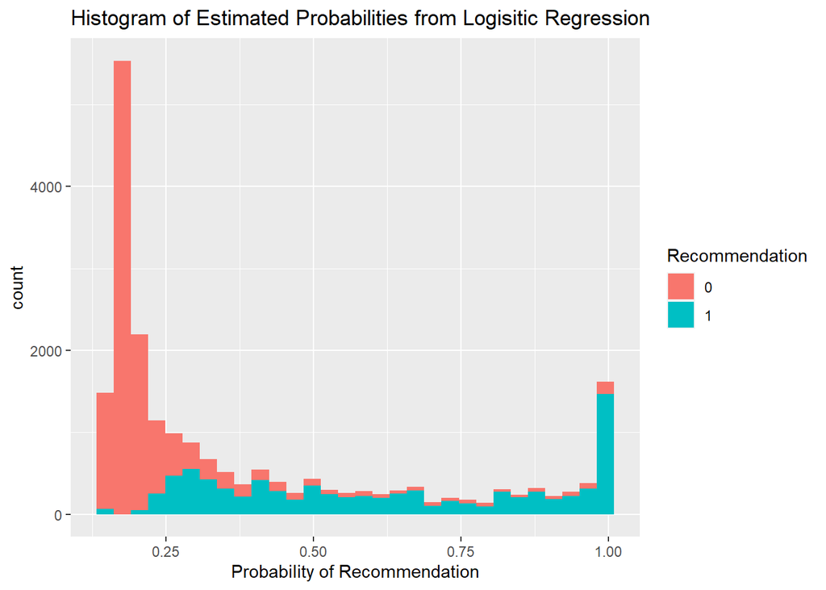

```r
recs = data.frame(simp_glm_views$fitted.values)
recs = list(recs)
recs = as.numeric(unlist(recs))

ggplot(train, aes(x=recs,fill= factor(simp_glm_views$y))) +
      geom_histogram() +
      labs(title = "Histogram of Estimated Probabilities from Logisitic Regression", x = "Probability of Recommendation") +
      scale_fill_discrete(name="Recommendation")
```

-*We can see that the number of `Votes` matters more than `Views`, as the mis-classification rate for `Views` is higher.*

### Decision Tree

##### Now we will train a decison tree and visualive the model.

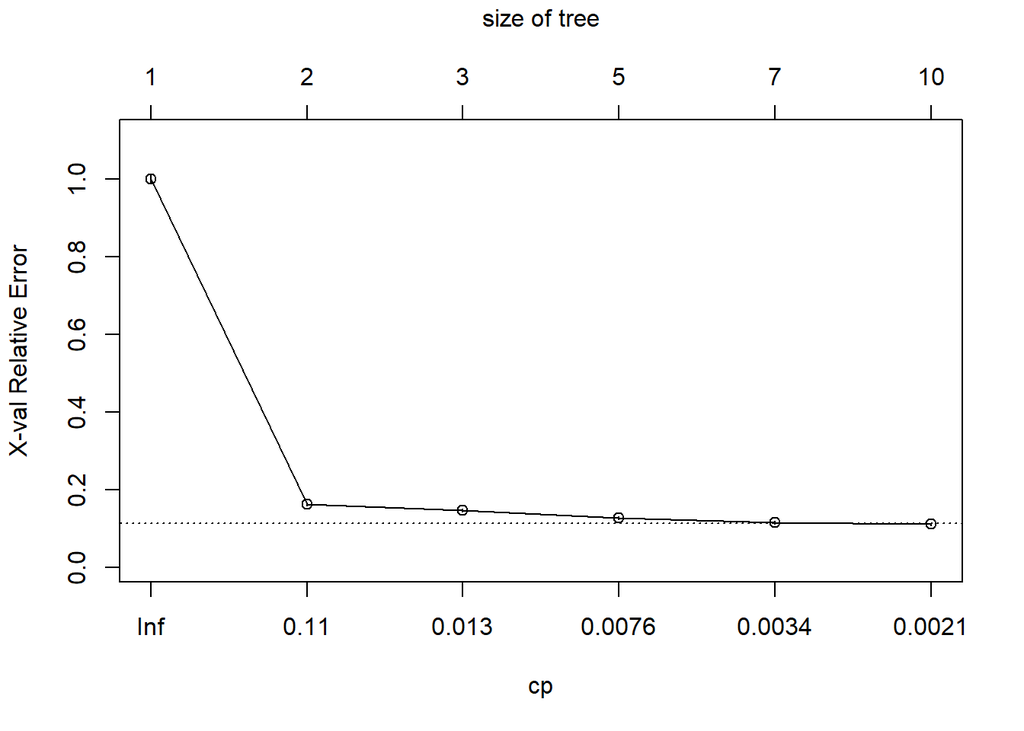

```r
tree_model <- rpart(as.factor(Recommended)~. , data = df_1)

tree_full <- rpart(as.factor(Recommended)~., data = df_1, subset = train_ind, control = rpart.control(minsplit = 100, cp = 0.002))


plotcp(tree_full)
```

-*Based on the size of tree, we need to take the point which is below the dash line, which is size of tree is 10. In other words, the optimal create of size tree is 10.*

```r
SE_1 <- which.min(tree_full$cptable[, "xerror"])

SE_2 <- tree_full$cptable[SE_1, "xerror"] + tree_full$cptable[SE_1, "xstd"]

(SE_1.index <- min(which(tree_full$cptable[, "xerror"] <= SE_2)))
```

```
## [1] 6
```

```r
(SE_1.cp <- tree_full$cptable[SE_1.index, "CP"])
```

```
## [1] 0.002
```

-*We use the rpart library to grow out a large tree, then use 1-SE rule to determine the least complex model that we can realistically use. In other words, above process is a plot of error vs. cp the dashed line represents the 1-SE error*

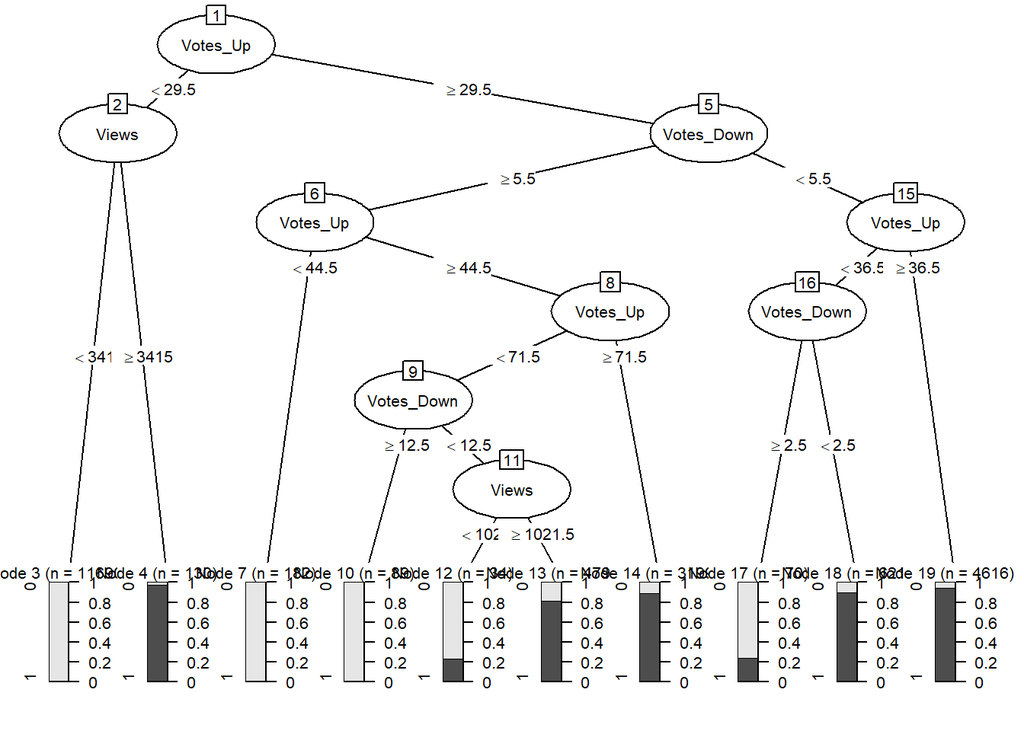

```r
tree_pruned <- prune(tree_full, cp = SE_1.cp)

tree_pruned.party <- as.party(tree_pruned)

plot(tree_pruned.party, gp = gpar(fontsize = 8))
```

-*The tree is fitted on the following variables: `Votes_Up`, `Views`, and `Votes_Down`. The bars at the bottom of the tree are very informative. Nodes 4, 13, 14, 18, and 19 resulted in a prediction of “Recommended”. Node 4 captures 130 suggestions, node 13 captures 479 suggestions, node 14 captures 3199 suggestions, node 18 captures 621 suggestions, and node 19 captures 4616 suggestions. The remaining 5 nodes resulted in predictions of not being recommended.*